# Stroke prediction with logistic regression

# Introduction

I want to implement a logistic regression model that can predict if a person is likely to get a stroke or not. The data set I use for this can be downloaded under [https://www.kaggle.com/datasets/fedesoriano/stroke-prediction-dataset].

Let’s first load the packages we will use:

```r
library(dplyr)
library(readr)
library(tidyr)
library(ggplot2)
library(cowplot)
library(caret)
library(lmPerm)
```

# Preparation

We load the data set and exam it.

```r
data <- read_csv('healthcare-dataset-stroke-data.csv')

dim(data)
```

```
## [1] 5110   12
```

```r
colnames(data)
```

```
##  [1] "id"                "gender"            "age"
##  [4] "hypertension"      "heart_disease"     "ever_married"
##  [7] "work_type"         "Residence_type"    "avg_glucose_level"
## [10] "bmi"               "smoking_status"    "stroke"
```

The data set contains 12 variables, with one column for the id, for 5110 observations. Our target variable is **stroke** coded as 0 if the patient did not have a stroke and 1 if he/she did.

```r
table(data$stroke)
```

```
##
##    0    1
## 4861  249
```

```r
round(mean(data$stroke), 3)
```

```
## [1] 0.049
```

```r
data$stroke <- factor(data$stroke)
```

This data set is highly unbalanced with only 249 of the 5110 (4.9%) having suffered from a stroke.

Since we have a manageable number of variables we will go through the rest of the columns one by one and look at their distribution and their relationship to the stroke column.

## Gender

```r
str(data$gender)
```

```
##  chr [1:5110] "Male" "Female" "Male" "Female" "Female" "Male" "Male" ...
```

```r
table(data$gender)
```

```
##
## Female   Male  Other
##   2994   2115      1
```

The first variable is the gender of the patient coded as ‘Male’, ‘Female’, and ‘Other’. Since there is only one observation containing ‘Other’ we will filter it out.

```r
data <- data %>%
  filter(gender != 'Other')

round(table(data$gender)/nrow(data), 2)
```

```
##
## Female   Male
##   0.59   0.41
```

The data set consists of 59% female and 41% male patients.

```r
gender_stroke <- data %>%
  select(gender, stroke) %>%
  table()

gender_stroke
```

```
##         stroke
## gender      0    1
##   Female 2853  141
##   Male   2007  108
```

```r
chisq.test(gender_stroke)
```

```
##
##  Pearson's Chi-squared test with Yates' continuity correction
##
## data:  gender_stroke
## X-squared = 0.34, df = 1, p-value = 0.5598
```

A confusion matrix of **gender** and **stroke** and a chi-squared test show that there is no association between both columns. We will therefore not use it in our model.

## Age

The next column is the age of the patient in years.

```r
str(data$age)
```

```
##  num [1:5109] 67 61 80 49 79 81 74 69 59 78 ...
```

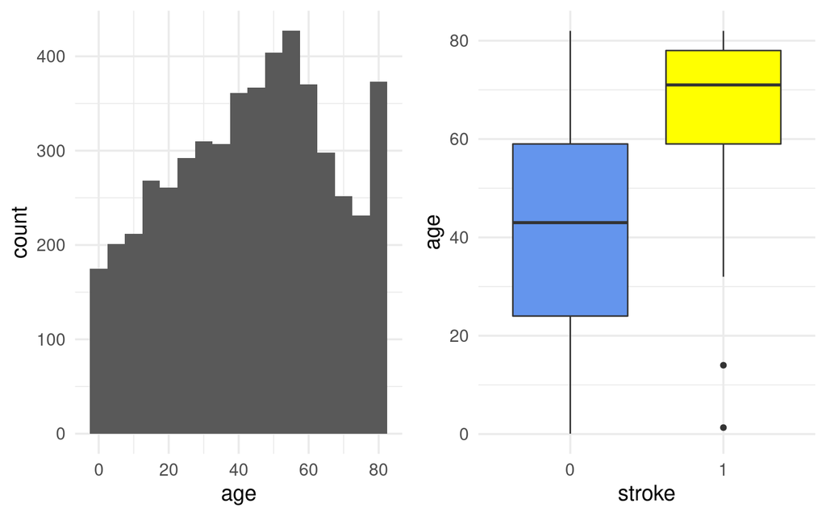

```r
A <- ggplot(data, aes(age))+
  geom_histogram(binwidth = 5)+
  theme_minimal(base_size = 15)

B <- ggplot(data, aes(stroke, age, fill = stroke))+
  geom_boxplot()+
  scale_fill_manual(values = c('cornflowerblue', 'yellow'))+
  theme_minimal(base_size = 15)+
  guides(fill = 'none')

plot_grid(A, B)
```

When we look at a histogram with a binwidth of 5 years we see that the distribution is skewed towards a higher age with a second peak at patients over 80.

We can also see a clear trend that patients who had a stroke were on average older than patients who did not have a stroke.

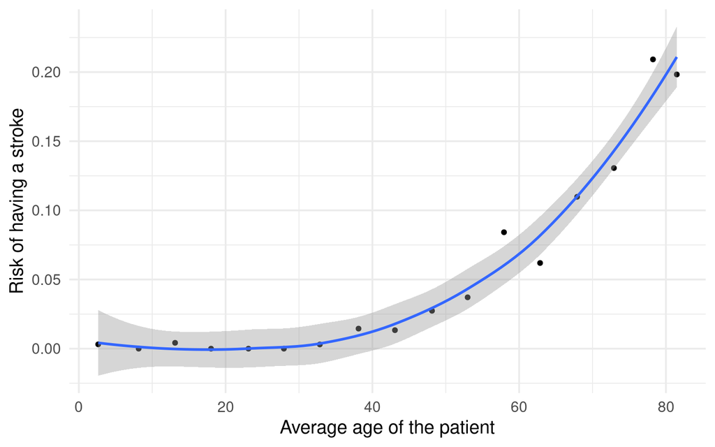

```r
data %>%
  mutate(age_group = ceiling(age/5)) %>%
  group_by(age_group) %>%
  summarize(risk = mean(stroke == 1),
            min_age = min(age),
            max_age = max(age),
            avg_age = mean(age)) %>%
  ungroup() %>%
  ggplot(aes(x = avg_age, y = risk))+
  geom_point()+
  geom_smooth()+
  theme_minimal(base_size = 15)+
  ylab('Risk of having a stroke')+
  xlab('Average age of the patient')
```

When we group the patients into age groups with a size of five years and calculate the risk of having a stroke as the percentage of patients who suffered from one, we can see that the risk is staying close to 0 until an age of 30 and then increases exponentially.

```r
anova(lmp(age ~ stroke, data = data))
```

```
## [1] "Settings:  unique SS "
## Analysis of Variance Table
##
## Response: age
##             Df R Sum Sq R Mean Sq Iter  Pr(Prob)
## stroke       1   157097    157097 5000 < 2.2e-16 ***
## Residuals 5107  2455000       481
## ---
## Signif. codes:  0 '***' 0.001 '**' 0.01 '*' 0.05 '.' 0.1 ' ' 1
```

```r
data$hypertension <- factor(data$hypertension)
```

As a statistical test for the association between **age** and **stroke** I chose an ANOVA with a permutation test, since we have highly unbalanced sample sizes for **stroke**. As expected from the visual examination of the data the average age of patients who suffered from a stroke differs significantly from the age of patients who did not.

## Hypertension

```r
str(data$hypertension)
```

```
##  Factor w/ 2 levels "0","1": 1 1 1 1 2 1 2 1 1 1 ...
```

```r
table(data$hypertension)
```

```
##
##    0    1
## 4611  498
```

```r
round(table(data$hypertension)/nrow(data), 2)
```

```
##
##   0   1
## 0.9 0.1
```

The next column **hypertension** is coded 0 if the patient does not have hypertension and 1 if he/she did. Only 10% of patients have hypertension.

```r
hypertension_stroke <- data %>%
  select(hypertension, stroke) %>%
  table()

hypertension_stroke
```

```
##             stroke
## hypertension    0    1
##            0 4428  183
##            1  432   66
```

```r
chisq.test(hypertension_stroke)
```

```
##
##  Pearson's Chi-squared test with Yates' continuity correction
##
## data:  hypertension_stroke
## X-squared = 81.573, df = 1, p-value < 2.2e-16
```

When looking at the confusion matrix between **hypertension** and **stroke**, we see that 13.3% of patients who have hypertension suffered from a stroke compared to the 4.0% of patients without hypertension. The chi-squared test between both variables is also highly significant.

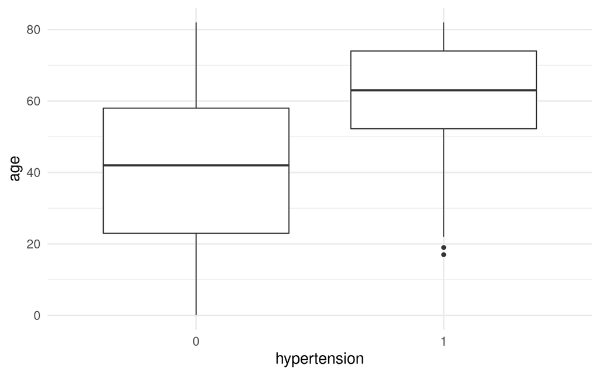

```r
ggplot(data, aes(hypertension,
                 age))+
  geom_boxplot()+
  theme_minimal(base_size = 15)
```

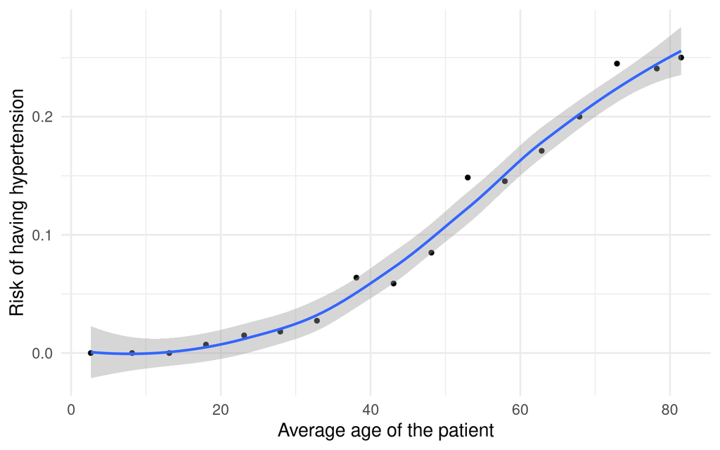

```r
data %>%
  mutate(age_group = ceiling(age/5)) %>%
  group_by(age_group) %>%
  summarize(risk = mean(hypertension == 1),
            min_age = min(age),
            max_age = max(age),
            avg_age = mean(age)) %>%
  ungroup() %>%
  ggplot(aes(x = avg_age, y = risk))+
  geom_point()+
  geom_smooth()+
  ylab('Risk of having hypertension')+
  xlab('Average age of the patient')+
  theme_minimal(base_size = 15)
```

When we look at the association between **hypertension** and **age**, we see that the average age of patients with hypertension is higher than of patients without hypertension. But if we look at the percentage of hypertension in age groups of five years we see a flatter increase as with **stroke** but starting earlier (at around 20 years).

```r
tmp <- data %>%
  filter(age <= 50)%>%
  select(hypertension, stroke) %>%
  table()

knitr::asis_output('### Patients younger than 50')
```

### Patients younger than 50

```r
round(tmp/rowSums(tmp), 2)
```

```
##             stroke
## hypertension    0    1
##            0 0.99 0.01
##            1 0.97 0.03
```

For patients younger than 50 3% of the patients with hypertension suffered from a stroke compared to the 1% without hypertension.

Therefore, if we include **hypertension** into our model it might be able to differentiate better between younger patients (below 50) who had a stroke and who did not.

## Heart disease

```r
str(data$heart_disease)
```

```
##  num [1:5109] 1 0 1 0 0 0 1 0 0 0 ...
```

```r
data$heart_disease <- factor(data$heart_disease)
table(data$heart_disease)
```

```
##
##    0    1
## 4833  276
```

```r
round(table(data$hypertension)/nrow(data), 2)
```

```
##
##   0   1
## 0.9 0.1
```

The next column **heart_disease** is coded as 0 if the patient does not have any heart disease and 1 if he/she does.

```r
heart_disease_stroke <- data %>%
  select(heart_disease, stroke) %>%
  table()

heart_disease_stroke
```

```
##              stroke
## heart_disease    0    1
##             0 4631  202
##             1  229   47
```

```r
chisq.test(heart_disease_stroke)
```

```
##
##  Pearson's Chi-squared test with Yates' continuity correction
##
## data:  heart_disease_stroke
## X-squared = 90.229, df = 1, p-value < 2.2e-16
```

The distribution of **heart_disease** is similar as in **stroke**. The confusion matrix and the chi-squared test show a strong association between **heart_disease** and **stroke**.

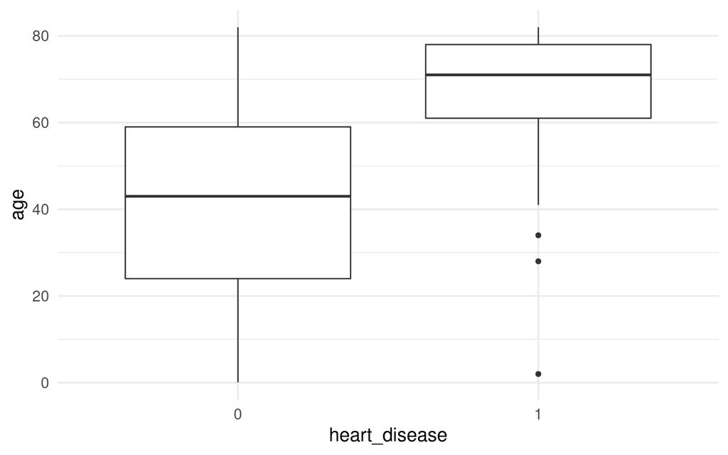

```r
ggplot(data, aes(heart_disease,
                 age))+
  geom_boxplot()+
  theme_minimal(base_size = 15)
```

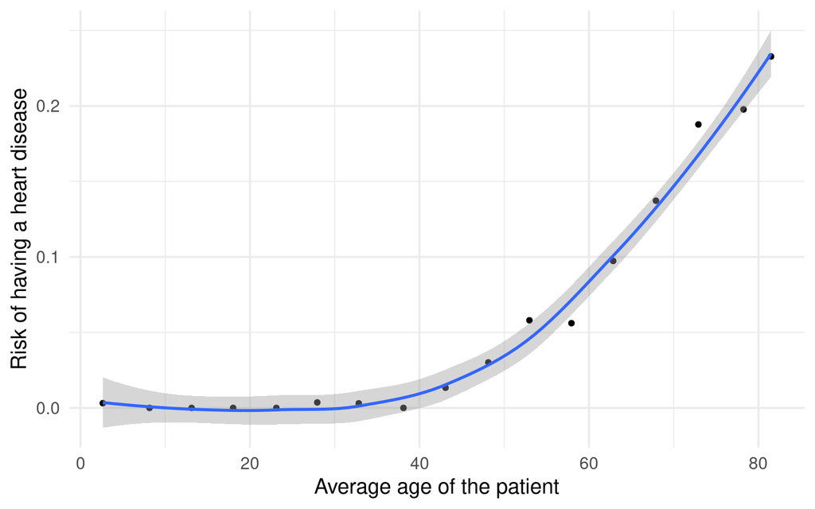

```r
data %>%
  mutate(age_group = ceiling(age/5)) %>%
  group_by(age_group) %>%
  summarize(risk = mean(heart_disease == 1),
            min_age = min(age),
            max_age = max(age),
            avg_age = mean(age)) %>%
  ungroup() %>%
  ggplot(aes(x = avg_age, y = risk))+
  geom_point()+
  geom_smooth()+
  ylab('Risk of having a heart disease')+
  xlab('Average age of the patient')+
  theme_minimal(base_size = 15)
```

When looking at the association between **heart_disease** and **age** in total and in age groups, we see both times a similar result as with **stroke**.

```r
tmp <- data %>%
  filter(age < 50) %>%
  select(heart_disease, stroke) %>%
  table()

knitr::asis_output('### Patients younger than 50')
```

### Patients younger than 50

```r
round(tmp/rowSums(tmp), 2)
```

```
##              stroke
## heart_disease    0    1
##             0 0.99 0.01
##             1 1.00 0.00
```

```r
tmp <- data %>%
  filter(age > 50)%>%
  select(heart_disease, stroke) %>%
  table()

knitr::asis_output('### Patients older than 50')
```

### Patients older than 50

```r
round(tmp/rowSums(tmp), 2)
```

```
##              stroke
## heart_disease    0    1
##             0 0.90 0.10
##             1 0.82 0.18
```

```r
knitr::asis_output('### All patients')
```

### All patients

```r
round(heart_disease_stroke/rowSums(heart_disease_stroke), 2)
```

```
##              stroke
## heart_disease    0    1
##             0 0.96 0.04
##             1 0.83 0.17
```

The confusion matrix between **heart_disease** and **stroke** for patients younger than 50 show that no patient with a heart disease had a stroke. The percentage of patients which suffered from both a stroke and have a heart disease is also the same for all patients and patients older than 50.

Therefore, I think that the column **heart_disease** will not bring any additional information for the prediction of a stroke.

## Marriage status

```r
str(data$ever_married)
```

```
##  chr [1:5109] "Yes" "Yes" "Yes" "Yes" "Yes" "Yes" "Yes" "No" "Yes" "Yes" ...
```

```r
round(table(data$ever_married)/nrow(data), 2)
```

```
##
##   No  Yes
## 0.34 0.66
```

```r
marriage_stroke <- data %>%
  select(ever_married, stroke) %>%
  table()

marriage_stroke
```

```
##             stroke
## ever_married    0    1
##          No  1727   29
##          Yes 3133  220
```

```r
chisq.test(marriage_stroke)
```

```
##
##  Pearson's Chi-squared test with Yates' continuity correction
##
## data:  marriage_stroke
## X-squared = 58.868, df = 1, p-value = 1.686e-14
```

Using the same approach as before we can see that people who are or have been married had a higher chance of suffering from a stroke.

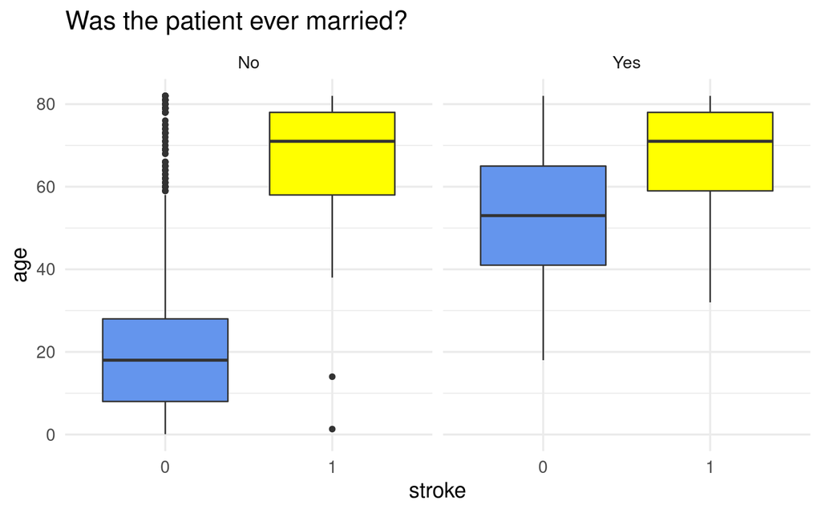

```r
ggplot(data, aes(stroke,
                 age,
                 fill = stroke))+
  geom_boxplot()+
  facet_grid(~ever_married)+
  scale_fill_manual(values = c('cornflowerblue', 'yellow'))+
  theme_minimal(base_size = 15)+
  labs(title = 'Was the patient ever married?')+
  guides(fill = 'none')
```

But when we also take the age of the patients into account we can see that people who were never married were simply younger and that within patients who are or have been married the ones who suffered from a stroke are also on average older.

Therefore this column adds no additional information and will not be included in the model.

## Work type

```r
str(data$work_type)
```

```
##  chr [1:5109] "Private" "Self-employed" "Private" "Private" "Self-employed" ...
```

```r
table(data$work_type)
```

```
##
##      children      Govt_job  Never_worked       Private Self-employed
##           687           657            22          2924           819
```

```r
round(table(data$work_type)/nrow(data), 2)
```

```
##
##      children      Govt_job  Never_worked       Private Self-employed
##          0.13          0.13          0.00          0.57          0.16
```

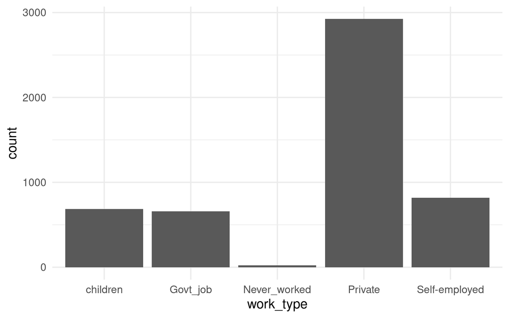

```r
ggplot(data, aes(x = work_type))+
  geom_bar()+
  theme_minimal(base_size = 15)
```

The column **work_type** contains information about the employment of the patients. The data contains children, patients working for the government (Govt_job), patients who never worked (Never_worked), and patients employed by the private sector (Private) or by themselves (Self-employed).

Most patients worked for the private sector (57%) and people who never worked are barely represented (< 1%). The other classes are fairly balanced.

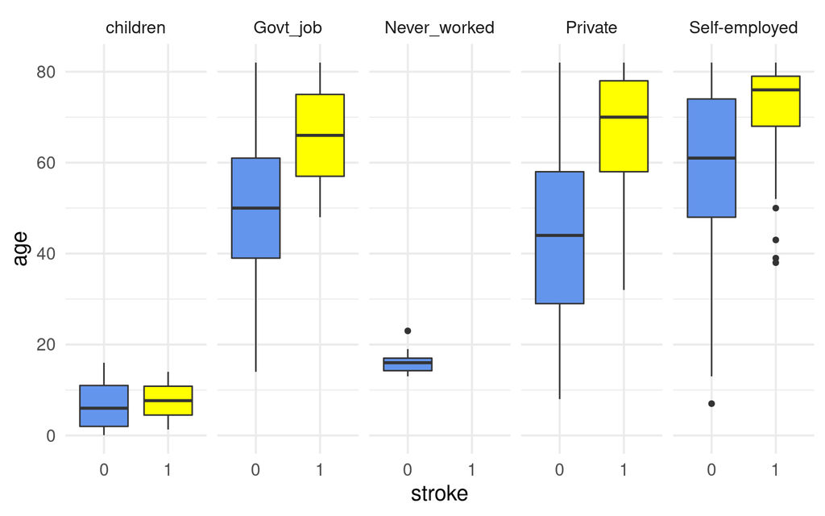

```r
ggplot(data, aes(stroke, age, fill = stroke))+
  geom_boxplot()+
  facet_grid(~work_type)+
  scale_fill_manual(values = c('cornflowerblue', 'yellow'))+
  theme_minimal(base_size = 15)+
  guides(fill = 'none')
```

```r
tmp <- table(data$work_type, data$stroke)
knitr::asis_output('### Share of people with a stroke per work type')
```

### Share of people with a stroke per work type

```r
round(tmp/rowSums(tmp), 2)
```

```
##
##                    0    1
##   children      1.00 0.00
##   Govt_job      0.95 0.05
##   Never_worked  1.00 0.00
##   Private       0.95 0.05
##   Self-employed 0.92 0.08
```

When looking at the association between **work_type** and **stroke** while also taking **age** into account, we see that it is mainly age separating the patients who suffered from a stroke from those who did not and not the work type. Only for children the average age of patients who suffered from a stroke and those who did not did not differ, but less than 1% of children suffered from a stroke.

Therefore, I decided not to include **work_type** into the model.

## Residence type

```r
str(data$Residence_type)
```

```
##  chr [1:5109] "Urban" "Rural" "Rural" "Urban" "Rural" "Urban" "Rural" ...
```

```r
table(data$Residence_type)
```

```
##
## Rural Urban
##  2513  2596
```

```r
round(table(data$Residence_type)/nrow(data), 2)
```

```
##
## Rural Urban
##  0.49  0.51
```

The column **Residence_type** informs us if the patient lives in a rural (49%) or an urban environment (51%).

```r
residence_stroke <- data %>%
  select(Residence_type, stroke) %>%
  table()

residence_stroke
```

```
##               stroke
## Residence_type    0    1
##          Rural 2399  114
##          Urban 2461  135
```

```r
chisq.test(residence_stroke)
```

```
##
##  Pearson's Chi-squared test with Yates' continuity correction
##
## data:  residence_stroke
## X-squared = 1.075, df = 1, p-value = 0.2998
```

It is not associated with **stroke** and will not be included in the model.

## Glucose level

```r
str(data$avg_glucose_level)
```

```
##  num [1:5109] 229 202 106 171 174 ...
```

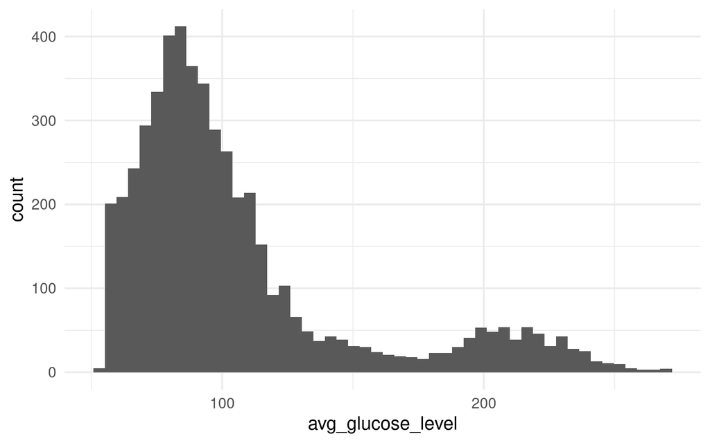

```r
ggplot(data, aes(avg_glucose_level))+
  geom_histogram(bins = 50)+
  theme_minimal(base_size = 15)
```

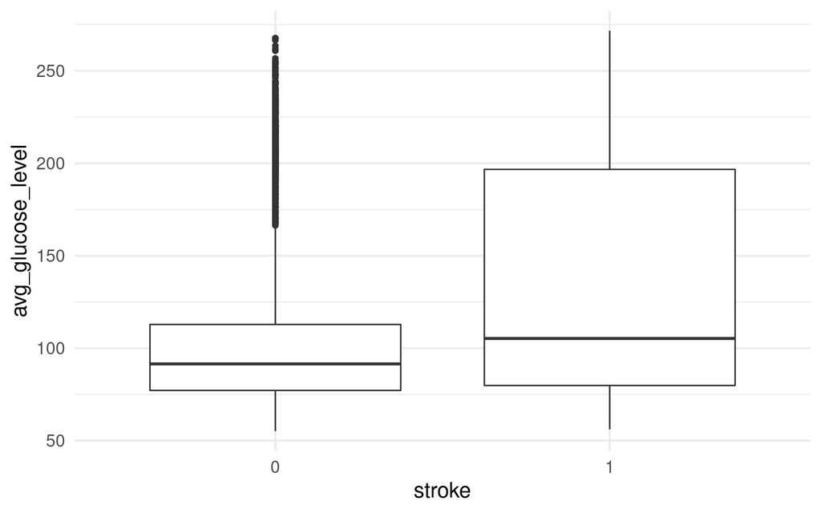

```r
ggplot(data, aes(x = stroke, y = avg_glucose_level))+
  geom_boxplot()+
  theme_minimal(base_size = 15)
```

```r
anova(lmp(avg_glucose_level ~ stroke, data = data))
```

```
## [1] "Settings:  unique SS "
## Analysis of Variance Table
##
## Response: avg_glucose_level
##             Df R Sum Sq R Mean Sq Iter  Pr(Prob)
## stroke       1   182494    182494 5000 < 2.2e-16 ***
## Residuals 5107 10292642      2015
## ---
## Signif. codes:  0 '***' 0.001 '**' 0.01 '*' 0.05 '.' 0.1 ' ' 1
```

```r
cat('Correlation between age and avg_glucose_level ', round(cor(data$age, data$avg_glucose_level), 2), '\n')
```

```
## Correlation between age and avg_glucose_level  0.24
```

Patients who suffered from a stroke have on average a higher average glucose level as shown in the boxplots and the ANOVA with a permutation test. It shows only a small positive correlation (r = 0.24) with age.

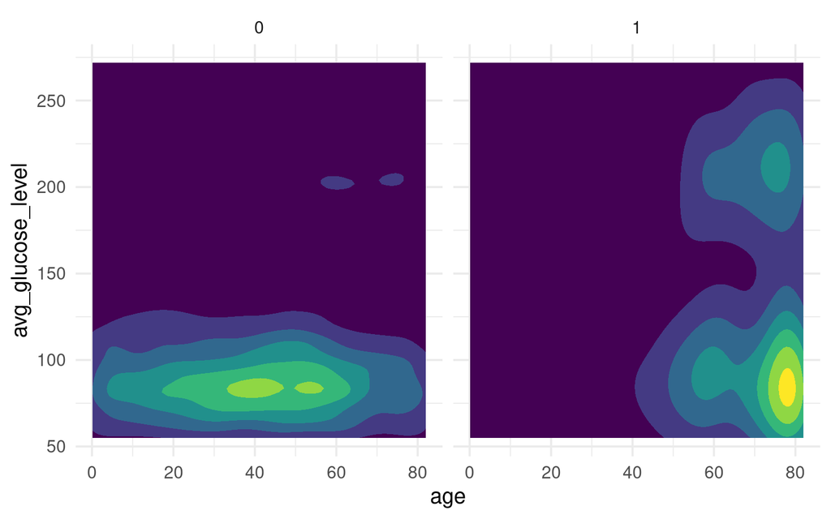

```r
ggplot(data, aes(age, avg_glucose_level))+
  geom_density2d_filled()+
  facet_grid(~stroke)+
  theme_minimal(base_size = 15)+
  theme(legend.position = 'none')
```

When looking at the 2D kernel density estimate of **age** and **avg_glucose_level** separated for patient who suffered from a stroke and those that did not, we can see that patients who had a stroke were on average older and/or had a higher average glucose level. Therefore, the average glucose level in the blood could help in our prediction.

## BMI

```r
str(data$bmi)
```

```
##  chr [1:5109] "36.6" "N/A" "32.5" "34.4" "24" "29" "27.4" "22.8" "N/A" ...
```

```r
NA_values <- unique(data$bmi[which(is.na(as.numeric(data$bmi)))])
NA_values
```

```
## [1] "N/A"
```

```r
data$bmi <- as.numeric(gsub(NA_values, NA, data$bmi))

sum(is.na(data$bmi))
```

```
## [1] 201
```

The column containing the body mass index (BMI) of the patients contains 201 missing values that needed recoding.

```r
knitr::asis_output('### Association between stroke and having a missing value at BMI')
```

### Association between stroke and having a missing value at BMI

```r
table(data$stroke, is.na(data$bmi))
```

```
##
##     FALSE TRUE
##   0  4699  161
##   1   209   40
```

```r
chisq.test(table(data$stroke, is.na(data$bmi)))
```

```
##
##  Pearson's Chi-squared test with Yates' continuity correction
##
## data:  table(data$stroke, is.na(data$bmi))
## X-squared = 98.559, df = 1, p-value < 2.2e-16
```

We can also see that the data is not missing at random, since patients with missing BMI values also suffered more often from a stroke (20.0%) compared to those without missing values (4.3%). Excluding the patients with missing values would make the data set even more unbalanced and a naive imputation method such as a median imputation would most likely lead to a bias in the prediction of **stroke** later.

```r
trc <- trainControl(method = 'cv',
             number = 5)

bmi_imputation_model <- train(bmi ~ .,
      method = 'ranger',
      data = data[!is.na(data$bmi), ],
      trControl = trc)

data$bmi[is.na(data$bmi)] <- predict(bmi_imputation_model,
                    newdata = data[is.na(data$bmi), ])
```

We therefore use all the other columns to perform an imputation with a random forest using the data without missing values as a training set with 5 times cross-validation and predict the missing BMI values. A random forest imputation has the advantage here that it can deal with the different data types and should out of the box give a more accurate imputation than just the median, since our sample size is sufficiently large.

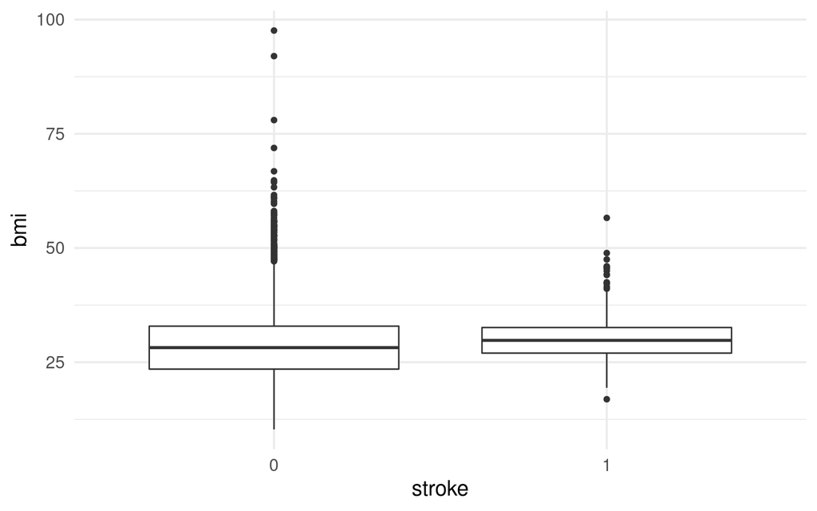

```r
ggplot(data, aes(stroke, bmi))+
  geom_boxplot()+
  theme_minimal(base_size = 15)
```

```r
anova(lmp(bmi ~ stroke, data = data))
```

```
## [1] "Settings:  unique SS "
## Analysis of Variance Table
##
## Response: bmi
##             Df R Sum Sq R Mean Sq Iter  Pr(Prob)
## stroke       1      549    548.84 5000 < 2.2e-16 ***
## Residuals 5107   304337     59.59
## ---
## Signif. codes:  0 '***' 0.001 '**' 0.01 '*' 0.05 '.' 0.1 ' ' 1
```

After imputation an ANOVA with a permutation test shows that patients with a stroke had on average a higher BMI. We will therefore include the BMI in our model.

## Smoking status

```r
str(data$smoking_status)
```

```
##  chr [1:5109] "formerly smoked" "never smoked" "never smoked" "smokes" ...
```

```r
table(data$smoking_status)
```

```
##
## formerly smoked    never smoked          smokes         Unknown
##             884            1892             789            1544
```

```r
data$smoking_status[data$smoking_status == 'Unknown'] <- NA
round(mean(is.na(data$smoking_status)), 3)
```

```
## [1] 0.302
```

The last column **smoking_status** informs us if the patient formerly smoked, never smoked or still smokes. The class ‘Unknown’ is recoded as NA, leading to a large amount of missing data (30.2%).

```r
round(table(data$work_type,
      data$smoking_status)/rowSums(table(data$work_type,
      data$smoking_status)), 2)
```

```
##
##                 formerly smoked never smoked smokes
##   children                 0.19         0.78   0.03
##   Govt_job                 0.25         0.53   0.22
##   Never_worked             0.00         1.00   0.00
##   Private                  0.23         0.53   0.24
##   Self-employed            0.31         0.50   0.19
```

```r
summary(data$age[data$work_type == 'children' &
                   !is.na(data$smoking_status)])
```

```
##    Min. 1st Qu.  Median    Mean 3rd Qu.    Max.
##   10.00   11.00   12.00   12.35   13.00   16.00
```

While checking for a connection between **smoking_status** and **work_type** for a possible association, I discovered that 19% of the patients marked as children are classified as ‘formerly smoked’ and 3% as ‘smokes’. Since 75% of patients marked as children are 13 years or younger and the maximum age is 16 years, I suspect some misclassification in the smoking status. This and the high amount of missing data suggest to exclude it from further analysis.

# Prediction

Now we want to use the variables **age**, **hypertension**, **avg_glucose_level**, and **bmi** to predict if a patient had a stroke or not. Since the data set is highly imbalanced, classifying all patients as having no stroke would lead to an accuracy of 0.95. Therefore it is important that we rather use the specifity (does the model classify all patients who had a stroke correctly) and the sensitivity (does the model classify all patients who did not have a stroke correctly?) to rank our models.

## Standard model

```r
data <- data %>%
  mutate(nr = 1:nrow(data),
         weights = ifelse(stroke == 1, 0.95, 0.05))

trc <- trainControl(method = 'repeatedcv',
                    number = 5,
                    repeats = 10,
             summaryFunction = twoClassSummary)

model_standard <- train(stroke ~ age + hypertension + avg_glucose_level + bmi,
      method = 'glm',
      trControl = trc,
      family = 'binomial',
      data = data,
      metric = 'Spec')

confusionMatrix(model_standard)
```

```
## Cross-Validated (5 fold, repeated 10 times) Confusion Matrix
##
## (entries are percentual average cell counts across resamples)
##
##           Reference
## Prediction    0    1
##          0 95.1  4.9
##          1  0.0  0.0
##
##  Accuracy (average) : 0.9513
```

As already expected the standard model classified all patients as not having a stroke leading to an accuracy of 0.95. This means, on the other Hand, that all patients who had a stroke were misclassified (specifity = 0).

## Weights and SMOTE

To solve the problem with the imbalanced data we will give the patients who suffered from a stroke a higher weight (0.95) compared to the ones who did not (0.05). As a second approach we will use SMOTE (Synthetic minority oversampling technique).

```r
model_weights <- train(stroke ~ age + hypertension + avg_glucose_level + bmi,
      method = 'glm',
      trControl = trc,
      family = 'binomial',
      weights = weights,
      data = data,
      metric = 'Spec')

trc_smote <- trainControl(method = 'repeatedcv',
             number = 5,
             repeats = 10,
             sampling = 'smote',
             summaryFunction = twoClassSummary)

model_smote <- train(stroke ~ age + hypertension + avg_glucose_level + bmi,
      method = 'glm',
      trControl = trc_smote,
      family = 'binomial',
      data = data,
      metric = 'Spec')


tmp <- resamples(list(standard = model_standard,
               weights = model_weights,
               smote = model_smote))

summary(tmp)[['statistics']][c('Spec', 'Sens')]
```

```
## $Spec
##               Min.   1st Qu.    Median      Mean 3rd Qu. Max. NA's
## standard 0.0000000 0.0000000 0.0000000 0.0000000    0.00 0.00    0
## weights  0.6530612 0.7638776 0.8000000 0.7987020    0.84 0.94    0
## smote    0.6530612 0.7600000 0.7979592 0.7918204    0.84 0.90    0
##
## $Sens
##               Min.   1st Qu.    Median      Mean   3rd Qu.      Max. NA's
## standard 1.0000000 1.0000000 1.0000000 1.0000000 1.0000000 1.0000000    0
## weights  0.6923868 0.7263374 0.7355967 0.7341564 0.7456276 0.7674897    0
## smote    0.7078189 0.7263374 0.7350823 0.7346914 0.7425412 0.7664609    0
```

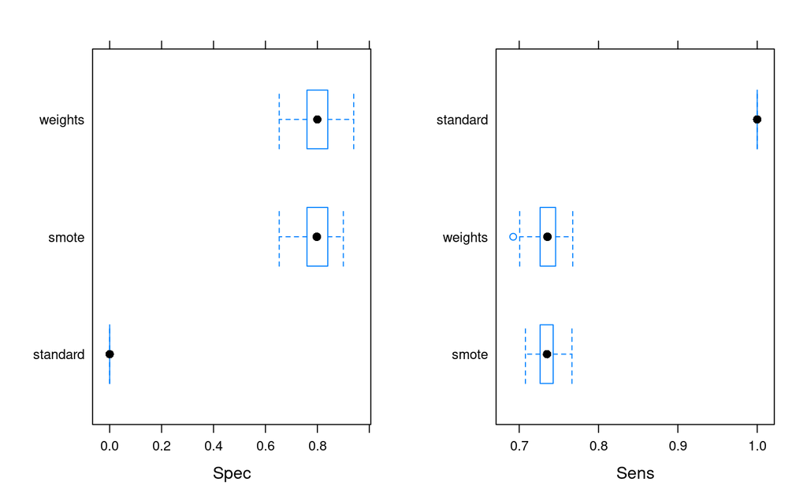

```r
A <- bwplot(tmp, metric = 'Spec')
B <- bwplot(tmp, metric = 'Sens')

plot_grid(A, B)
```

Both approaches improve the specifity of the model to 0.79 while decreasing its sensitivity to 0.73. This means that more patients who did not have a stroke are misclassified, but most patients who had a stroke were correctly classified.

## Regularization

We can try to improve the logistic regression by also using two regularization approaches, namely ridge and lasso regression.

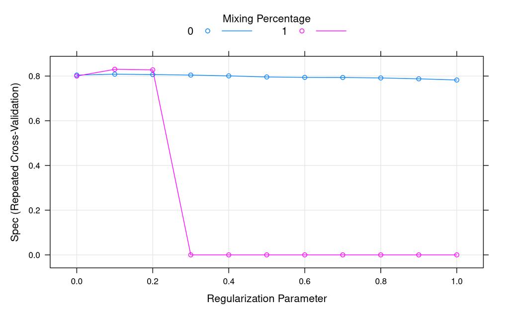

```r
model_weights_reg <- train(stroke ~ age + hypertension + avg_glucose_level + bmi,
      method = 'glmnet',
      trControl = trc,
      family = 'binomial',
      weights = weights,
      data = data,
      metric = 'Spec',
      tuneGrid = expand.grid(
        alpha = c(0, 1),
        lambda = 0:10/10
      ))

model_smote_reg <- train(stroke ~ age + hypertension + avg_glucose_level + bmi,
      method = 'glmnet',
      trControl = trc_smote,
      family = 'binomial',
      data = data,
      metric = 'Spec',
      tuneGrid = expand.grid(
        alpha = c(0, 1),
        lambda = 0:10/10
      ))

plot(model_weights_reg)
```

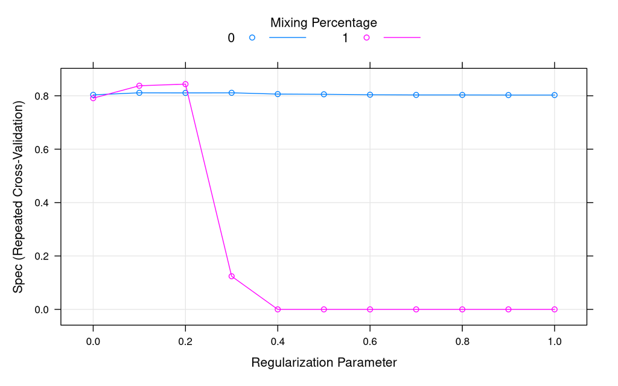

```r
plot(model_smote_reg)
```

Both the approach with weights and with SMOTE optimized the specifity using lasso regression. Let’s see how they perform compared to the previous models.

```r
tmp <- resamples(list(standard = model_standard,
                      weights = model_weights,
               smote = model_smote,
               weights_reg = model_weights_reg,
               smote_reg = model_smote_reg))



summary(tmp)[['statistics']][c('Spec', 'Sens')]
```

```
## $Spec
##                  Min.   1st Qu.    Median      Mean 3rd Qu. Max. NA's
## standard    0.0000000 0.0000000 0.0000000 0.0000000    0.00 0.00    0
## weights     0.6530612 0.7638776 0.8000000 0.7987020    0.84 0.94    0
## smote       0.6530612 0.7600000 0.7979592 0.7918204    0.84 0.90    0
## weights_reg 0.6400000 0.8000000 0.8200000 0.8301224    0.86 0.96    0
## smote_reg   0.7142857 0.8040816 0.8485714 0.8436408    0.88 0.96    0
##
## $Sens
##                  Min.   1st Qu.    Median      Mean   3rd Qu.      Max. NA's
## standard    1.0000000 1.0000000 1.0000000 1.0000000 1.0000000 1.0000000    0
## weights     0.6923868 0.7263374 0.7355967 0.7341564 0.7456276 0.7674897    0
## smote       0.7078189 0.7263374 0.7350823 0.7346914 0.7425412 0.7664609    0
## weights_reg 0.6728395 0.6995885 0.7067901 0.7082305 0.7211934 0.7386831    0
## smote_reg   0.6460905 0.6779835 0.6934156 0.6918107 0.7042181 0.7304527    0
```

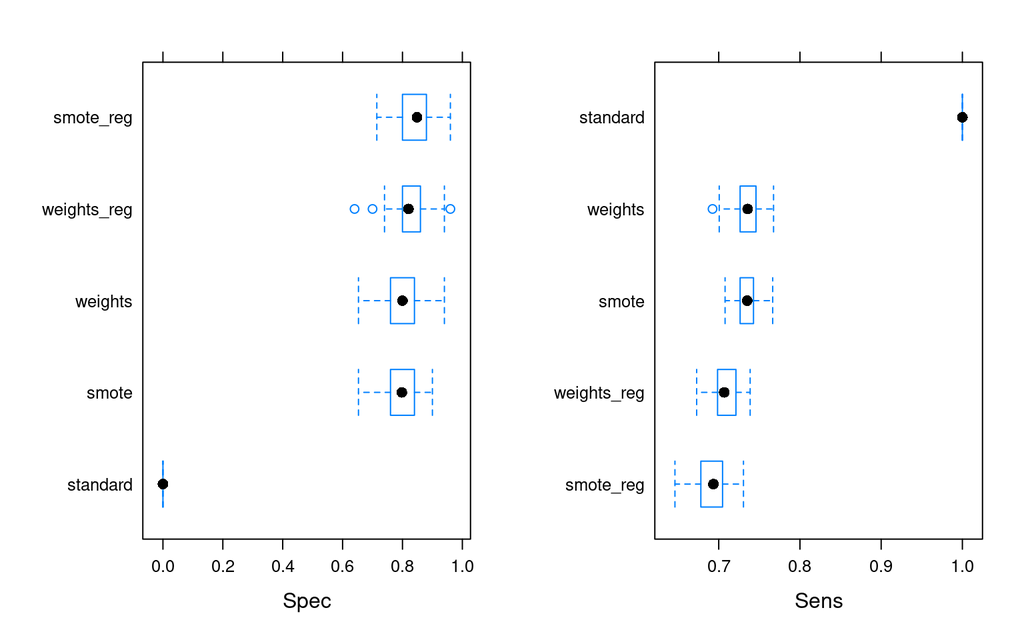

```r
A <- bwplot(tmp, metric = 'Spec')

B <- bwplot(tmp, metric = 'Sens')

plot_grid(A, B)
```

```r
knitr::asis_output('### Balanced accuracy')
```

### Balanced accuracy

```r
round((summary(tmp)[['statistics']][['Sens']][, 'Mean'] + summary(tmp)[['statistics']][['Spec']][, 'Mean'])/2, 2)
```

```
##    standard     weights       smote weights_reg   smote_reg
##        0.50        0.77        0.76        0.77        0.77
```